# The analysis of the 2014-2015 NBA Finals and the number of crimes in Oakland, CA

-- Research Question:

- Was there an association between the number of crimes in Oakland, CA in 2015 and the 2014-2015 NBA Finals?

-- Citation:

- Crime Data 2015 (2016). Oakland Support Team: City of Oakland. Retrieved from: https://data.oaklandnet.com/Public-Safety/Crime-Data-2015/957n-urxz
- June 2014-2015 NBA Schedule and Results (2015). Basketball-Reference: Sportradar. Retrieved from: https://www.basketball-reference.com/leagues/NBA_2015_games-june.html
- no_finals.csv (2020). Created by Romano Robles

-- Additional Information:

- The crime data set contains a compilation of all crimes reported in Oakland, California in 2015. It includes the timestamp of when the crime occurred, the crime type, the place it occurred, and the case number.
- The 2014-2015 NBA schedule data set contains all of the information regarding the 2014-2015 NBA finals. It includes the teams, the date and time it started, the number of attendees, the scores, and etc.
- For the NBA schedule data set, I manually changed the time column from (Start ET) to (Start PT) to reflect the same timezone from the crime data set and since it's a small data set. I did try using python to get the same results but I wasn't able to get around the errors that I was getting from down the road.
- The control group data set contains dates that are a week prior or after of the game occurred. (eg. the control group for the game on Jun 4 will be the week prior since there's a game a week after Jun 4.)
- Also, I created my own csv file for the control group and I have no use of the schedule data set after the data clean up section. I did use it for my reference but I didn't touch the data frame after merging the two.

```python
# Import modules
import pandas as pd
import numpy as np
import datetime
from functools import reduce
from pandas.io.json import json_normalize
import json
import matplotlib.pyplot as plt
%matplotlib inline
# Ignore SettingWithCopyWarning
pd.options.mode.chained_assignment = None
```

## Data Clean Up:

```python
# Read in csv files
crime = pd.read_csv('/Users/romanor/Desktop/INST447/Prog_4/Crime_Data_2015.csv')
finals = pd.read_csv('/Users/romanor/Desktop/INST447/Prog_4/finals_2014.csv')
no_finals = pd.read_csv('/Users/romanor/Desktop/INST447/Prog_4/no_finals_2015.csv')
```

```python
# Print first few rows of both data sets
print(crime.head())
print(finals.head())
print(no_finals.head())
```

```
                  CRIMETYPE                DATETIME CASENUMBER  \
0       MISDEMEANOR ASSAULT  01/01/2015 12:00:00 AM  15-000098
1        DISORDERLY CONDUCT  01/01/2015 12:00:00 AM  15-000304
2  FORGERY & COUNTERFEITING  01/01/2015 12:00:00 AM  15-002086
3                     OTHER  01/01/2015 12:00:00 AM  15-003479
4        DISORDERLY CONDUCT  01/01/2015 12:00:00 AM  15-004084

                 DESCRIPTION POLICEBEAT             LOCATION     CITY STATE
0          DISTURB THE PEACE        35X  8400 MACARTHUR BLVD  Oakland    CA
1          DISTURB THE PEACE        10Y          810 60TH ST  Oakland    CA
2  OBT CREDIT/ETC:OTHER'S ID        30Y     6900 BANCROFT AV  Oakland    CA
3             FOUND PROPERTY        27X    5223 BELVEDERE ST  Oakland    CA
4          DISTURB THE PEACE        30X         1929 73RD AV  Oakland    CA
                Date Start (PT)        Visitor/Neutral  PTS  \
0   Thu, Jun 4, 2015      6:00p    Cleveland Cavaliers  100
```

[output cut: 17 more lines]

```python
# Format datetime from the data sets
crime[['Date','Time']] = crime['DATETIME'].str.split(' ', 1, expand=True)
crime["Date"] = pd.to_datetime(crime["Date"]).apply(lambda x:x.strftime('%m/%d/%Y'))
crime["Time"] = pd.to_datetime(crime["Time"]).apply(lambda x:x.strftime('%H:%M:%S'))
finals["Date"] = pd.to_datetime(finals["Date"]).apply(lambda x:x.strftime('%m/%d/%Y'))
finals["Time"] = pd.to_datetime(finals["Start (PT)"]).apply(lambda x:x.strftime('%H:%M:%S'))
no_finals["Date"] = pd.to_datetime(no_finals["Date"]).apply(lambda x:x.strftime('%m/%d/%Y'))
```

```python
# Drop unnecessary columns
crime = crime[['CASENUMBER', 'CRIMETYPE', 'Date', 'Time']]
finals = finals[['Date', 'Time']]
```

```python
# Merge finals and no_finals data sets
schedule = pd.merge(finals, no_finals, how='outer', on=['Date'])
# Print first few rows of the data sets
print(crime.head())
print(schedule.head)
```

```
  CASENUMBER                 CRIMETYPE        Date      Time
0  15-000098       MISDEMEANOR ASSAULT  01/01/2015  00:00:00
1  15-000304        DISORDERLY CONDUCT  01/01/2015  00:00:00
2  15-002086  FORGERY & COUNTERFEITING  01/01/2015  00:00:00
3  15-003479                     OTHER  01/01/2015  00:00:00
4  15-004084        DISORDERLY CONDUCT  01/01/2015  00:00:00
<bound method NDFrame.head of           Date      Time
0   06/04/2015  18:00:00
1   06/07/2015  17:00:00
2   06/09/2015  18:00:00
3   06/11/2015  18:00:00
4   06/14/2015  17:00:00
5   06/16/2015  18:00:00
6   05/28/2015       NaN
7   05/31/2015       NaN
8   06/02/2015       NaN
9   06/18/2015       NaN
10  06/21/2015       NaN
11  06/23/2015       NaN>
```

## Data Aggregation:

### Number of Crimes on 2014-2015 NBA Finals Game 1 (Home):

```python
# Subset the crime data set 2 hours before, during, and after Game 1 on 06/04/2015 18:00:00
game1 = crime.loc[(crime['Date'] == '06/04/2015') & ((crime['Time'] >= '16:00:00') & (crime['Time'] <= '23:00:00'))]
```

```python
# Adjust the values to get the numbers of crime reported per hour
# eg. all crimes reported in between 16:00:00 and 17:00:00 will be considered reported at the 16:00:00 hour
game1.loc[(game1['Time'] >= '16:00:00') & (game1['Time'] < '17:00:00')] = '16:00:00'
game1.loc[(game1['Time'] >= '17:00:00') & (game1['Time'] < '18:00:00')] = '17:00:00'
game1.loc[(game1['Time'] >= '18:00:00') & (game1['Time'] < '19:00:00')] = '18:00:00'
game1.loc[(game1['Time'] >= '19:00:00') & (game1['Time'] < '20:00:00')] = '19:00:00'
game1.loc[(game1['Time'] >= '20:00:00') & (game1['Time'] < '21:00:00')] = '20:00:00'
game1.loc[(game1['Time'] >= '21:00:00') & (game1['Time'] < '22:00:00')] = '21:00:00'
game1.loc[(game1['Time'] >= '22:00:00') & (game1['Time'] < '23:00:00')] = '22:00:00'
game1.loc[(game1['Time'] >= '23:00:00')] = '23:00:00'
```

```python
# Calculate how many crimes were reported 2 hours before, during, and after Game 1 on 06/04/2016 18:00:00
game1_crime = game1[["Time", "CASENUMBER"]].groupby(["Time"]).agg("count")
# Reset index and rename columns
game1_crime = game1_crime.reset_index()
game1_crime.columns = ['Time', 'Num of Crimes']
# Print first few rows
game1_crime.head()
```

|  | Time | Num of Crimes |
| --- | --- | --- |
| 0 | 16:00:00 | 15 |
| 1 | 17:00:00 | 7 |
| 2 | 18:00:00 | 18 |
| 3 | 19:00:00 | 10 |
| 4 | 20:00:00 | 6 |

### Number of Crimes on 2014-2015 NBA FInals Game 2 (Home):

```python
# Subset the crime data set 2 hours before, during, and after Game 2 on 06/07/2015 17:00:00
game2 = crime.loc[(crime['Date'] == '06/07/2015') & ((crime['Time'] >= '15:00:00') & (crime['Time'] <= '22:00:00'))]
```

```python
# Adjust the values to get the numbers of crime reported per hour
# eg. all crimes reported in between 16:00:00 and 17:00:00 will be considered reported at 16:00:00 hour
game2.loc[(game2['Time'] >= '15:00:00') & (game2['Time'] < '16:00:00')] = '15:00:00'
game2.loc[(game2['Time'] >= '16:00:00') & (game2['Time'] < '17:00:00')] = '16:00:00'
game2.loc[(game2['Time'] >= '17:00:00') & (game2['Time'] < '18:00:00')] = '17:00:00'
game2.loc[(game2['Time'] >= '18:00:00') & (game2['Time'] < '19:00:00')] = '18:00:00'
game2.loc[(game2['Time'] >= '19:00:00') & (game2['Time'] < '20:00:00')] = '19:00:00'
game2.loc[(game2['Time'] >= '20:00:00') & (game2['Time'] < '21:00:00')] = '20:00:00'
game2.loc[(game2['Time'] >= '21:00:00') & (game2['Time'] < '22:00:00')] = '21:00:00'
game2.loc[(game2['Time'] >= '22:00:00')] = '22:00:00'
```

```python
# Calculate how many crimes were reported 2 hours before, during, and after Game 2 on 06/07/2016 17:00:00
game2_crime = game2[["Time", "CASENUMBER"]].groupby(["Time"]).agg("count")
# Reset index and rename columns
game2_crime = game2_crime.reset_index()
game2_crime.columns = ['Time', 'Num of Crimes']
# Print first few rows
game2_crime.head()
```

|  | Time | Num of Crimes |
| --- | --- | --- |
| 0 | 15:00:00 | 9 |
| 1 | 16:00:00 | 11 |
| 2 | 17:00:00 | 5 |
| 3 | 18:00:00 | 4 |
| 4 | 19:00:00 | 8 |

### Number of Crimes on 2014-2015 NBA FInals Game 3 (Away):

```python
# Subset the crime data set 2 hours before, during, and after Game 3 on 06/09/2015 18:00:00
game3 = crime.loc[(crime['Date'] == '06/09/2015') & ((crime['Time'] >= '16:00:00') & (crime['Time'] <= '23:00:00'))]
```

```python
# Adjust the values to get the numbers of crime reported per hour
# eg. all crimes reported in between 16:00:00 and 17:00:00 will be considered reported at 16:00:00 hour
game3.loc[(game3['Time'] >= '16:00:00') & (game3['Time'] < '17:00:00')] = '16:00:00'
game3.loc[(game3['Time'] >= '17:00:00') & (game3['Time'] < '18:00:00')] = '17:00:00'
game3.loc[(game3['Time'] >= '18:00:00') & (game3['Time'] < '19:00:00')] = '18:00:00'
game3.loc[(game3['Time'] >= '19:00:00') & (game3['Time'] < '20:00:00')] = '19:00:00'
game3.loc[(game3['Time'] >= '20:00:00') & (game3['Time'] < '21:00:00')] = '20:00:00'
game3.loc[(game3['Time'] >= '21:00:00') & (game3['Time'] < '22:00:00')] = '21:00:00'
game3.loc[(game3['Time'] >= '22:00:00') & (game3['Time'] < '23:00:00')] = '22:00:00'
game3.loc[(game3['Time'] >= '23:00:00')] = '23:00:00'
```

```python
# Calculate how many crimes were reported 2 hours before, during, and after game 3 starting on 06/09/2016 18:00:00
game3_crime = game3[["Time", "CASENUMBER"]].groupby(["Time"]).agg("count")
# Reset index and rename columns
game3_crime = game3_crime.reset_index()
game3_crime.columns = ['Time', 'Num of Crimes']
# Print first few rows
game3_crime.head()
```

|  | Time | Num of Crimes |
| --- | --- | --- |
| 0 | 16:00:00 | 19 |
| 1 | 17:00:00 | 14 |
| 2 | 18:00:00 | 15 |
| 3 | 19:00:00 | 5 |
| 4 | 20:00:00 | 16 |

### Number of Crimes on 2014-2015 NBA FInals Game 4 (Away):

```python
# Subset the crime data set 2 hours before, during, and after Game 4 on 06/11/2015 18:00:00
game4 = crime.loc[(crime['Date'] == '06/11/2015') & ((crime['Time'] >= '16:00:00') & (crime['Time'] <= '23:00:00'))]
```

```python
# Adjust the values to get the numbers of crime reported per hour
# eg. all crimes reported in between 16:00:00 and 17:00:00 will be considered reported at 16:00:00 hour
game4.loc[(game4['Time'] >= '16:00:00') & (game4['Time'] < '17:00:00')] = '16:00:00'
game4.loc[(game4['Time'] >= '17:00:00') & (game4['Time'] < '18:00:00')] = '17:00:00'
game4.loc[(game4['Time'] >= '18:00:00') & (game4['Time'] < '19:00:00')] = '18:00:00'
game4.loc[(game4['Time'] >= '19:00:00') & (game4['Time'] < '20:00:00')] = '19:00:00'
game4.loc[(game4['Time'] >= '20:00:00') & (game4['Time'] < '21:00:00')] = '20:00:00'
game4.loc[(game4['Time'] >= '21:00:00') & (game4['Time'] < '22:00:00')] = '21:00:00'
game4.loc[(game4['Time'] >= '22:00:00') & (game4['Time'] < '23:00:00')] = '22:00:00'
game4.loc[(game4['Time'] >= '23:00:00')] = '23:00:00'
```

```python
# Calculate how many crimes were reported 2 hours before, during, and after Game 4 on 06/11/2016 18:00:00
game4_crime = game4[["Time", "CASENUMBER"]].groupby(["Time"]).agg("count")
# Reset index and rename columns
game4_crime = game4_crime.reset_index()
game4_crime.columns = ['Time', 'Num of Crimes']
# Print first few rows
game4_crime.head()
```

|  | Time | Num of Crimes |
| --- | --- | --- |
| 0 | 16:00:00 | 14 |
| 1 | 17:00:00 | 9 |
| 2 | 18:00:00 | 14 |
| 3 | 19:00:00 | 5 |
| 4 | 20:00:00 | 14 |

### Number of Crimes on 2014-2015 NBA FInals Game 5 (Home):

```python
# Subset the crime data set 2 hours before, during, and after Game 5 on 06/14/2015 17:00:00
game5 = crime.loc[(crime['Date'] == '06/14/2015') & ((crime['Time'] >= '15:00:00') & (crime['Time'] <= '22:00:00'))]
```

```python
# Adjust the values to get the numbers of crime reported per hour
# eg. all crimes reported in between 16:00:00 and 17:00:00 will be considered reported at 16:00:00 hour
game5.loc[(game5['Time'] >= '15:00:00') & (game5['Time'] < '16:00:00')] = '15:00:00'
game5.loc[(game5['Time'] >= '16:00:00') & (game5['Time'] < '17:00:00')] = '16:00:00'
game5.loc[(game5['Time'] >= '17:00:00') & (game5['Time'] < '18:00:00')] = '17:00:00'
game5.loc[(game5['Time'] >= '18:00:00') & (game5['Time'] < '19:00:00')] = '18:00:00'
game5.loc[(game5['Time'] >= '19:00:00') & (game5['Time'] < '20:00:00')] = '19:00:00'
game5.loc[(game5['Time'] >= '20:00:00') & (game5['Time'] < '21:00:00')] = '20:00:00'
game5.loc[(game5['Time'] >= '21:00:00') & (game5['Time'] < '22:00:00')] = '21:00:00'
game5.loc[(game5['Time'] >= '22:00:00')] = '22:00:00'
```

```python
# Calculate how many crimes were reported 2 hours before, during, and after game 5 on 06/14/2016 17:00:00
game5_crime = game5[["Time", "CASENUMBER"]].groupby(["Time"]).agg("count")
# Reset index and rename columns
game5_crime = game5_crime.reset_index()
game5_crime.columns = ['Time', 'Num of Crimes']
# Print first few rows
game5_crime.head()
```

|  | Time | Num of Crimes |
| --- | --- | --- |
| 0 | 15:00:00 | 12 |
| 1 | 16:00:00 | 8 |
| 2 | 17:00:00 | 11 |
| 3 | 18:00:00 | 9 |
| 4 | 19:00:00 | 2 |

### Number of Crimes on 2014-2015 NBA FInals Game 6 (Home):

```python
# Subset the crime data set 2 hours before, during, and after Game 6 on 06/16/2015 18:00:00
game6 = crime.loc[(crime['Date'] == '06/16/2015') & ((crime['Time'] >= '16:00:00') & (crime['Time'] <= '23:00:00'))]
```

```python
# Adjust the values to get the numbers of crime reported per hour
# eg. all crimes reported in between 16:00:00 and 17:00:00 will be considered reported at 16:00:00 hour
game6.loc[(game6['Time'] >= '16:00:00') & (game6['Time'] < '17:00:00')] = '16:00:00'
game6.loc[(game6['Time'] >= '17:00:00') & (game6['Time'] < '18:00:00')] = '17:00:00'
game6.loc[(game6['Time'] >= '18:00:00') & (game6['Time'] < '19:00:00')] = '18:00:00'
game6.loc[(game6['Time'] >= '19:00:00') & (game6['Time'] < '20:00:00')] = '19:00:00'
game6.loc[(game6['Time'] >= '20:00:00') & (game6['Time'] < '21:00:00')] = '20:00:00'
game6.loc[(game6['Time'] >= '21:00:00') & (game6['Time'] < '22:00:00')] = '21:00:00'
game6.loc[(game6['Time'] >= '22:00:00') & (game6['Time'] < '23:00:00')] = '22:00:00'
game6.loc[(game6['Time'] >= '23:00:00')] = '23:00:00'
```

```python
# Calculate how many crimes were reported 2 hours before, during, and after game 6 on 06/16/2016 18:00:00
game6_crime = game6[["Time", "CASENUMBER"]].groupby(["Time"]).agg("count")
# Reset index and rename columns
game6_crime = game6_crime.reset_index()
game6_crime.columns = ['Time', 'Num of Crimes']
# Print first few rows
game6_crime.head()
```

|  | Time | Num of Crimes |
| --- | --- | --- |
| 0 | 16:00:00 | 8 |
| 1 | 17:00:00 | 12 |
| 2 | 18:00:00 | 10 |
| 3 | 19:00:00 | 4 |
| 4 | 20:00:00 | 3 |

### Number of Crimes on No 2014-2015 NBA FInals Game 1:

```python
# Subset the crime data set 2 hours before, during, and after, the control group for Game 1 on 05/28/2015 18:00:00
no_game1 = crime.loc[(crime['Date'] == '05/28/2015') & ((crime['Time'] >= '16:00:00') & (crime['Time'] <= '23:00:00'))]
```

```python
# Adjust the values to get the numbers of crime reported per hour
# eg. all crimes reported in between 16:00:00 and 17:00:00 will be considered reported at 16:00:00 hour
no_game1.loc[(no_game1['Time'] >= '16:00:00') & (no_game1['Time'] < '17:00:00')] = '16:00:00'
no_game1.loc[(no_game1['Time'] >= '17:00:00') & (no_game1['Time'] < '18:00:00')] = '17:00:00'
no_game1.loc[(no_game1['Time'] >= '18:00:00') & (no_game1['Time'] < '19:00:00')] = '18:00:00'
no_game1.loc[(no_game1['Time'] >= '19:00:00') & (no_game1['Time'] < '20:00:00')] = '19:00:00'
no_game1.loc[(no_game1['Time'] >= '20:00:00') & (no_game1['Time'] < '21:00:00')] = '20:00:00'
no_game1.loc[(no_game1['Time'] >= '21:00:00') & (no_game1['Time'] < '22:00:00')] = '21:00:00'
no_game1.loc[(no_game1['Time'] >= '22:00:00') & (no_game1['Time'] < '23:00:00')] = '22:00:00'
no_game1.loc[(no_game1['Time'] >= '23:00:00')] = '23:00:00'
```

```python
# Calculate how many crimes were reported 2 hours before, during, and after, the control group for Game 1 starting on on 05/28/2015 18:00:00
no_game1_crime = no_game1[["Time", "CASENUMBER"]].groupby(["Time"]).agg("count")
# Reset index and rename columns
no_game1_crime = no_game1_crime.reset_index()
no_game1_crime.columns = ['Time', 'Num of Crimes']
# Print first few rows
no_game1_crime.head()
```

|  | Time | Num of Crimes |
| --- | --- | --- |
| 0 | 16:00:00 | 11 |
| 1 | 17:00:00 | 25 |
| 2 | 18:00:00 | 19 |
| 3 | 19:00:00 | 11 |
| 4 | 20:00:00 | 16 |

### Number of Crimes on No 2014-2015 NBA FInals Game 2:

```python
# Subset the crime data set 2 hours before, during, and after, the control group for Game 2 on 05/31/2015 17:00:00
no_game2 = crime.loc[(crime['Date'] == '05/31/2015') & ((crime['Time'] >= '15:00:00') & (crime['Time'] <= '22:00:00'))]
```

```python
# Adjust the values to get the numbers of crime reported per hour
# eg. all crimes reported in between 16:00:00 and 17:00:00 will be considered reported at 16:00:00 hour
no_game2.loc[(no_game2['Time'] >= '15:00:00') & (no_game2['Time'] < '16:00:00')] = '15:00:00'
no_game2.loc[(no_game2['Time'] >= '16:00:00') & (no_game2['Time'] < '17:00:00')] = '16:00:00'
no_game2.loc[(no_game2['Time'] >= '17:00:00') & (no_game2['Time'] < '18:00:00')] = '17:00:00'
no_game2.loc[(no_game2['Time'] >= '18:00:00') & (no_game2['Time'] < '19:00:00')] = '18:00:00'
no_game2.loc[(no_game2['Time'] >= '19:00:00') & (no_game2['Time'] < '20:00:00')] = '19:00:00'
no_game2.loc[(no_game2['Time'] >= '20:00:00') & (no_game2['Time'] < '21:00:00')] = '20:00:00'
no_game2.loc[(no_game2['Time'] >= '21:00:00') & (no_game2['Time'] < '22:00:00')] = '21:00:00'
no_game2.loc[(no_game2['Time'] >= '22:00:00')] = '22:00:00'
```

```python
# Calculate how many crimes were reported 2 hours before, during, and after, the control group for Game 2 starting on on 05/31/2015 17:00:00
no_game2_crime = no_game2[["Time", "CASENUMBER"]].groupby(["Time"]).agg("count")
# Reset index and rename columns
no_game2_crime = no_game2_crime.reset_index()
no_game2_crime.columns = ['Time', 'Num of Crimes']
# Print first few rows
no_game2_crime.head()
```

|  | Time | Num of Crimes |
| --- | --- | --- |
| 0 | 15:00:00 | 12 |
| 1 | 16:00:00 | 14 |
| 2 | 17:00:00 | 11 |
| 3 | 18:00:00 | 13 |
| 4 | 19:00:00 | 16 |

### Number of Crimes on No 2014-2015 NBA FInals Game 3:

```python
# Subset the crime data set 2 hours before, during, and after, the control group for Game 3 on 06/02/2015 18:00:00
no_game3 = crime.loc[(crime['Date'] == '06/02/2015') & ((crime['Time'] >= '16:00:00') & (crime['Time'] <= '23:00:00'))]
```

```python
# Adjust the values to get the numbers of crime reported per hour
# eg. all crimes reported in between 16:00:00 and 17:00:00 will be considered reported at 16:00:00 hour
no_game3.loc[(no_game3['Time'] >= '16:00:00') & (no_game3['Time'] < '17:00:00')] = '16:00:00'
no_game3.loc[(no_game3['Time'] >= '17:00:00') & (no_game3['Time'] < '18:00:00')] = '17:00:00'
no_game3.loc[(no_game3['Time'] >= '18:00:00') & (no_game3['Time'] < '19:00:00')] = '18:00:00'
no_game3.loc[(no_game3['Time'] >= '19:00:00') & (no_game3['Time'] < '20:00:00')] = '19:00:00'
no_game3.loc[(no_game3['Time'] >= '20:00:00') & (no_game3['Time'] < '21:00:00')] = '20:00:00'
no_game3.loc[(no_game3['Time'] >= '21:00:00') & (no_game3['Time'] < '22:00:00')] = '21:00:00'
no_game3.loc[(no_game3['Time'] >= '22:00:00') & (no_game3['Time'] < '23:00:00')] = '22:00:00'
no_game3.loc[(no_game3['Time'] >= '23:00:00')] = '23:00:00'
```

```python
# Calculate how many crimes were reported 2 hours before, during, and after, the control group for Game 3 starting on on 06/02/2015 18:00:00
no_game3_crime = no_game3[["Time", "CASENUMBER"]].groupby(["Time"]).agg("count")
# Reset index and rename columns
no_game3_crime = no_game3_crime.reset_index()
no_game3_crime.columns = ['Time', 'Num of Crimes']
# Print first few rows
no_game3_crime.head()
```

|  | Time | Num of Crimes |
| --- | --- | --- |
| 0 | 16:00:00 | 22 |
| 1 | 17:00:00 | 17 |
| 2 | 18:00:00 | 14 |
| 3 | 19:00:00 | 10 |
| 4 | 20:00:00 | 15 |

### Number of Crimes on No 2014-2015 NBA FInals Game 4:

```python
# Subset the crime data set 2 hours before, during, and after, the control group for Game 4 on 06/18/2015 18:00:00
no_game4 = crime.loc[(crime['Date'] == '06/18/2015') & ((crime['Time'] >= '16:00:00') & (crime['Time'] <= '23:00:00'))]
```

```python
# Adjust the values to get the numbers of crime reported per hour
# eg. all crimes reported in between 16:00:00 and 17:00:00 will be considered reported at 16:00:00 hour
no_game4.loc[(no_game4['Time'] >= '16:00:00') & (no_game4['Time'] < '17:00:00')] = '16:00:00'
no_game4.loc[(no_game4['Time'] >= '17:00:00') & (no_game4['Time'] < '18:00:00')] = '17:00:00'
no_game4.loc[(no_game4['Time'] >= '18:00:00') & (no_game4['Time'] < '19:00:00')] = '18:00:00'
no_game4.loc[(no_game4['Time'] >= '19:00:00') & (no_game4['Time'] < '20:00:00')] = '19:00:00'
no_game4.loc[(no_game4['Time'] >= '20:00:00') & (no_game4['Time'] < '21:00:00')] = '20:00:00'
no_game4.loc[(no_game4['Time'] >= '21:00:00') & (no_game4['Time'] < '22:00:00')] = '21:00:00'
no_game4.loc[(no_game4['Time'] >= '22:00:00') & (no_game4['Time'] < '23:00:00')] = '22:00:00'
no_game4.loc[(no_game4['Time'] >= '23:00:00')] = '23:00:00'
```

```python
# Calculate how many crimes were reported 2 hours before, during, and after, the control group for Game 4 starting on on 06/18/2015 18:00:00
no_game4_crime = no_game4[["Time", "CASENUMBER"]].groupby(["Time"]).agg("count")
# Reset index and rename columns
no_game4_crime = no_game4_crime.reset_index()
no_game4_crime.columns = ['Time', 'Num of Crimes']
# Print first few rows
no_game4_crime.head()
```

|  | Time | Num of Crimes |
| --- | --- | --- |
| 0 | 16:00:00 | 17 |
| 1 | 17:00:00 | 8 |
| 2 | 18:00:00 | 12 |
| 3 | 19:00:00 | 28 |
| 4 | 20:00:00 | 16 |

### Number of Crimes on No 2014-2015 NBA FInals Game 5:

```python
# Subset the crime data set 2 hours before, during, and after, the control group for Game 5 on 06/21/2015 17:00:00
no_game5 = crime.loc[(crime['Date'] == '06/21/2015') & ((crime['Time'] >= '15:00:00') & (crime['Time'] <= '22:00:00'))]
```

```python
# Adjust the values to get the numbers of crime reported per hour
# eg. all crimes reported in between 16:00:00 and 17:00:00 will be considered reported at 16:00:00 hour
no_game5.loc[(no_game5['Time'] >= '15:00:00') & (no_game5['Time'] < '16:00:00')] = '15:00:00'
no_game5.loc[(no_game5['Time'] >= '16:00:00') & (no_game5['Time'] < '17:00:00')] = '16:00:00'
no_game5.loc[(no_game5['Time'] >= '17:00:00') & (no_game5['Time'] < '18:00:00')] = '17:00:00'
no_game5.loc[(no_game5['Time'] >= '18:00:00') & (no_game5['Time'] < '19:00:00')] = '18:00:00'
no_game5.loc[(no_game5['Time'] >= '19:00:00') & (no_game5['Time'] < '20:00:00')] = '19:00:00'
no_game5.loc[(no_game5['Time'] >= '20:00:00') & (no_game5['Time'] < '21:00:00')] = '20:00:00'
no_game5.loc[(no_game5['Time'] >= '21:00:00') & (no_game5['Time'] < '22:00:00')] = '21:00:00'
no_game5.loc[(no_game5['Time'] >= '22:00:00')] = '22:00:00'
```

```python
# Calculate how many crimes were reported 2 hours before, during, and after, the control group for Game 5 starting on on 06/21/2015 17:00:00
no_game5_crime = no_game5[["Time", "CASENUMBER"]].groupby(["Time"]).agg("count")
# Reset index and rename columns
no_game5_crime = no_game5_crime.reset_index()
no_game5_crime.columns = ['Time', 'Num of Crimes']
# Print first few rows
no_game5_crime.head()
```

|  | Time | Num of Crimes |
| --- | --- | --- |
| 0 | 15:00:00 | 8 |
| 1 | 16:00:00 | 7 |
| 2 | 17:00:00 | 9 |
| 3 | 18:00:00 | 10 |
| 4 | 19:00:00 | 10 |

### Number of Crimes on No 2014-2015 NBA FInals Game 6:

```python
# Subset the crime data set 2 hours before, during, and after, the control group for Game 6 on 06/23/2015 18:00:00
no_game6 = crime.loc[(crime['Date'] == '06/23/2015') & ((crime['Time'] >= '16:00:00') & (crime['Time'] <= '23:00:00'))]
```

```python
# Adjust the values to get the numbers of crime reported per hour
# eg. all crimes reported in between 16:00:00 and 17:00:00 will be considered reported at 16:00:00 hour
no_game6.loc[(no_game6['Time'] >= '16:00:00') & (no_game6['Time'] < '17:00:00')] = '16:00:00'
no_game6.loc[(no_game6['Time'] >= '17:00:00') & (no_game6['Time'] < '18:00:00')] = '17:00:00'
no_game6.loc[(no_game6['Time'] >= '18:00:00') & (no_game6['Time'] < '19:00:00')] = '18:00:00'
no_game6.loc[(no_game6['Time'] >= '19:00:00') & (no_game6['Time'] < '20:00:00')] = '19:00:00'
no_game6.loc[(no_game6['Time'] >= '20:00:00') & (no_game6['Time'] < '21:00:00')] = '20:00:00'
no_game6.loc[(no_game6['Time'] >= '21:00:00') & (no_game6['Time'] < '22:00:00')] = '21:00:00'
no_game6.loc[(no_game6['Time'] >= '22:00:00') & (no_game6['Time'] < '23:00:00')] = '22:00:00'
no_game6.loc[(no_game6['Time'] >= '23:00:00')] = '23:00:00'
```

```python
# Calculate how many crimes were reported 2 hours before, during, and after, the control group for Game 6 starting on on 06/23/2015 18:00:00
no_game6_crime = no_game6[["Time", "CASENUMBER"]].groupby(["Time"]).agg("count")
# Reset index and rename columns
no_game6_crime = no_game6_crime.reset_index()
no_game6_crime.columns = ['Time', 'Num of Crimes']
# Print first few rows
no_game6_crime.head()
```

|  | Time | Num of Crimes |
| --- | --- | --- |
| 0 | 16:00:00 | 24 |
| 1 | 17:00:00 | 8 |
| 2 | 18:00:00 | 10 |
| 3 | 19:00:00 | 8 |
| 4 | 20:00:00 | 8 |

## Data Summarization:

```python
# Compile all NBA finals games crime data sets for merging
nba_finals_crime= [game1_crime, game2_crime, game3_crime, game4_crime, game5_crime, game6_crime]
```

```python
# Merge all Num of Crimes columns into one data frame to calculate the average number of crimes reported per hour
# Solution found from: https://stackoverflow.com/questions/44327999/python-pandas-merge-multiple-dataframes
crime_finals = reduce(lambda  left,right: pd.merge(left,right,on=['Time'], how='outer'), nba_finals_crime)
```

```python
# Calculate the total and the average number of crimes reported and add it to a new column
crime_finals['Total Crime'] = crime_finals[['Num of Crimes_x', 'Num of Crimes_y']].sum(1)
```

```python
# Drop unnecessary columns
crime_finals = crime_finals[['Time', 'Total Crime']]
# Print first few rows
crime_finals.head()
```

|  | Time | Total Crime |
| --- | --- | --- |
| 0 | 16:00:00 | 75.0 |
| 1 | 17:00:00 | 58.0 |
| 2 | 18:00:00 | 70.0 |
| 3 | 19:00:00 | 34.0 |
| 4 | 20:00:00 | 66.0 |

```python
# Compile all NBA finals games crime data sets for merging
no_nba_finals_crime= [no_game1_crime, no_game2_crime, no_game3_crime, no_game4_crime, no_game5_crime, no_game6_crime]
```

```python
# Merge all Num of Crimes columns into one data frame to calculate the average number of crimes reported per hour
# Solution found from: https://stackoverflow.com/questions/44327999/python-pandas-merge-multiple-dataframes
crime_no_finals = reduce(lambda  left,right: pd.merge(left,right,on=['Time'], how='outer'), no_nba_finals_crime)
```

```python
# Calculate the total and the average number of crimes reported and add it to a new column
crime_no_finals['Total Crime'] = crime_no_finals[['Num of Crimes_x', 'Num of Crimes_y']].sum(1)
```

```python
# Drop unnecessary columns
crime_no_finals = crime_no_finals[['Time', 'Total Crime']]
# Print first few rows
crime_no_finals.head()
# Drop unnecessary columns
```

|  | Time | Total Crime |
| --- | --- | --- |
| 0 | 16:00:00 | 95.0 |
| 1 | 17:00:00 | 78.0 |
| 2 | 18:00:00 | 78.0 |
| 3 | 19:00:00 | 83.0 |
| 4 | 20:00:00 | 81.0 |

### Percent Change on Crimes:

```python
# Merge crime_finals and crime_no_finals data sets
merged_crime = pd.merge(crime_finals, crime_no_finals, how='inner', on=['Time'], suffixes=['_finals', '_no_finals'])
merged_crime.head()
```

|  | Time | Total Crime_finals | Total Crime_no_finals |
| --- | --- | --- | --- |
| 0 | 16:00:00 | 75.0 | 95.0 |
| 1 | 17:00:00 | 58.0 | 78.0 |
| 2 | 18:00:00 | 70.0 | 78.0 |
| 3 | 19:00:00 | 34.0 | 83.0 |
| 4 | 20:00:00 | 66.0 | 81.0 |

```python
# Calculate the percent change (((formula = # of crimes on no NBA finals - # of crimes on NBA finals))/# of crimes on NBA finals)*100)
merged_crime['Pct Change_total'] = (((merged_crime['Total Crime_no_finals'] - merged_crime['Total Crime_finals'])/merged_crime['Total Crime_finals'])*100)
# Print first few rows
merged_crime.head()
```

|  | Time | Total Crime_finals | Total Crime_no_finals | Pct Change_total |
| --- | --- | --- | --- | --- |
| 0 | 16:00:00 | 75.0 | 95.0 | 26.666667 |
| 1 | 17:00:00 | 58.0 | 78.0 | 34.482759 |
| 2 | 18:00:00 | 70.0 | 78.0 | 11.428571 |
| 3 | 19:00:00 | 34.0 | 83.0 | 144.117647 |
| 4 | 20:00:00 | 66.0 | 81.0 | 22.727273 |

## Data Visualization:

### Total Crimes on 2014-2015 NBA Finals vs. Crimes on No 2014-2015 NBA Finals:

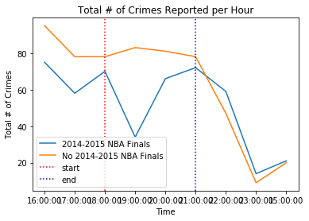

```python
# Plot the data sets
plt.plot(crime_finals['Time'], crime_finals['Total Crime'], label='2014-2015 NBA Finals')
plt.plot(crime_no_finals['Time'], crime_no_finals['Total Crime'], label='No 2014-2015 NBA Finals')
plt.xlabel("Time")
plt.ylabel("Total # of Crimes")
plt.title("Total # of Crimes Reported per Hour")
# Plot vertical lines for start and end times
# Solution found from: https://stackoverflow.com/questions/24988448/how-to-draw-vertical-lines-on-a-given-plot-in-matplotlib
plt.axvline(x=2, linestyle='dotted', color='red', label='start')
plt.axvline(x=5, linestyle='dotted', color='blue', label='end')
# Add legends
plt.legend(loc="lower left")
```

## Data Analysis:

#### Analysis:

-- Was there an association between the number of crime rates in Oakland, California in 2015 and the 2014-2015 NBA Finals?

#### Limitation:

- There many factors that may affect the change in the number of crimes. The changes may not only occur during the NBA final games but may be in other sports events, concerts, or etc. The city officials can not solely use the NBA final games as a reason in the change of the numbers. This study has many rooms for improvement.